# Introduction to StatComp21055

兰敬国 SA21229031

2021-12-22

## Overview

**StatComp21055** 是统计计算课程的期末`R`包。 它主要包括包括三个部分:

- 首先是关于shapes data 的一些统计量的计算，包括均值计算、回归估计和模型选择(决定系数$R^2$)。
- 第二是几个有关变量选择的一些批量化处理函数，方便平时跑模拟。大致分为3个部分: 数据生成，指标计算和画图输出。
- 第三是平时作业汇总(见`homework.html`)

## shapes data

shapes data就是形状数据。我们想做的事情是, 比如大脑某些结构的形状, 比较常用的表示方式是坐标法, 在轮廓边缘取一些点来刻画形状(landmark法)。

我们想研究的是响应变量是shape data的情景下, 把欧氏空间的一些方法推广过来。 比如对一组大脑患有疾病的患者,我们想研究大脑某个部位的形状与患者的性别、年龄、病情是否有关，以此确定该疾病是否会影响大脑的某个部位，进而制定相应策略医治。

我们通过两张图来加深了解:

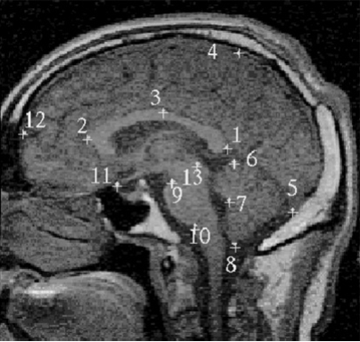

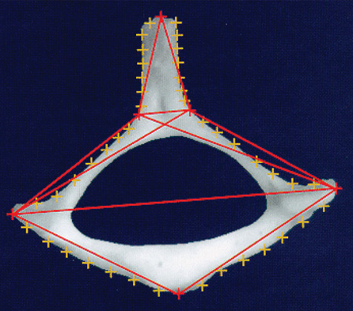

brains 数据集

- 形状数据: brains$x 24*3*58
- 年龄: brains$age
- 性别: brains$sex (1 for male / 2 for female)
- 组别: brains$grp

```r
library(StatComp21055)
library(BB)
library(shapes)
library(frechet)
data("brains")
## 以年龄、性别和组别作为预测变量
X=cbind(brains$age,brains$grp,brains$sex)[1:10,]
Y=brains$x[,,1:10]
## 预览一下shapes data 的样子
print(Y[,,1])
```

```
##       [,1] [,2] [,3]
##  [1,]   80 23.5   59
##  [2,]   69 18.5   73
##  [3,]   68 19.5   63
##  [4,]   95 48.5   51
##  [5,]   97 45.5   61
##  [6,]   98 43.5   67
##  [7,]   86 61.5   91
##  [8,]   92 34.5   49
##  [9,]   66 46.5   83
## [10,]   66 42.5   37
## [11,]   68 31.5   94
## [12,]   69 18.5   78
## [13,]   55 20.5   58
## [14,]   65 18.5   77
## [15,]   63 18.5   66
## [16,]   41 46.5   47
## [17,]   35 45.5   53
## [18,]   35 40.5   64
## [19,]   46 60.5   88
## [20,]   40 31.5   51
## [21,]   65 44.5   86
## [22,]   63 42.5   35
## [23,]   64 31.5   95
## [24,]   64 18.5   80
```

### 计算一下均值

```r
Fm=Fmean(Y)
Fm
```

```
##           [,1]     [,2]     [,3]
##  [1,] 77.95930 27.16843 61.73238
##  [2,] 66.59319 23.86436 74.58517
##  [3,] 66.57467 23.20933 65.50242
##  [4,] 90.60380 54.38759 48.05084
##  [5,] 94.37873 52.66132 55.99395
##  [6,] 95.99074 50.83840 64.27690
##  [7,] 87.52588 70.62805 87.35683
##  [8,] 89.55561 39.56270 49.32377
##  [9,] 65.35925 56.68658 84.99198
## [10,] 63.40072 48.45568 36.25782
## [11,] 66.49587 43.54147 98.36996
## [12,] 66.86656 26.83772 83.37686
## [13,] 50.12583 26.83323 62.76042
## [14,] 60.81293 24.81068 77.30652
## [15,] 60.59260 23.34109 67.93050
## [16,] 35.34878 54.50689 50.04849
## [17,] 32.45477 51.99939 56.38213
## [18,] 32.75101 50.39036 65.75819
## [19,] 39.44420 71.27715 87.13116
## [20,] 37.36723 39.99944 51.18100
## [21,] 63.34218 55.06467 85.29719
## [22,] 61.00315 48.86261 35.19115
## [23,] 60.61861 43.41920 98.46526
## [24,] 60.63412 25.75398 83.52928
```

### 回归估计

```r
## 预测一下自变量是X[1,]处的Y值
yhat=FREShape(Y,X,X[1,])

cbind(Y[,,1],yhat)
```

```
##       [,1] [,2] [,3]     [,4]     [,5]     [,6]
##  [1,]   80 23.5   59 79.28772 28.25237 60.57748
##  [2,]   69 18.5   73 66.51428 24.47849 74.99500
##  [3,]   68 19.5   63 66.43632 24.07128 66.01625
##  [4,]   95 48.5   51 92.67381 53.40821 49.00932
##  [5,]   97 45.5   61 94.26174 51.79255 57.12669
##  [6,]   98 43.5   67 95.96899 50.23292 65.85457
##  [7,]   86 61.5   91 86.33949 71.81468 87.24627
##  [8,]   92 34.5   49 89.49049 39.92399 49.26563
##  [9,]   66 46.5   83 65.83559 57.23068 85.08875
## [10,]   66 42.5   37 63.22134 49.19305 35.53090
## [11,]   68 31.5   94 66.21061 42.93926 96.42460
## [12,]   69 18.5   78 67.68401 26.62084 82.83224
## [13,]   55 20.5   58 49.83766 26.91196 62.17280
## [14,]   65 18.5   77 61.21212 24.77235 78.60420
## [15,]   63 18.5   66 59.93923 23.23056 68.63002
## [16,]   41 46.5   47 34.88847 54.11105 50.59359
## [17,]   35 45.5   53 31.52754 52.15763 56.92642
## [18,]   35 40.5   64 33.11375 50.52988 67.11565
## [19,]   46 60.5   88 39.37169 72.19224 86.26190
## [20,]   40 31.5   51 36.39543 40.09221 51.20312
## [21,]   65 44.5   86 63.90219 54.40254 85.36255
## [22,]   63 42.5   35 59.96226 47.89982 34.20438
## [23,]   64 31.5   95 61.08346 42.66579 97.20333
## [24,]   64 18.5   80 60.64047 25.17464 82.55320
```

### 模型估计

针对不同的预测变量我们可以建立不同的模型，所以需要有个指标衡量哪个模型更好。能从欧氏空间借鉴的是决定系数($R^2$)或者调整后的决定系数($adj-R^2$)。决定系数越大说明模型拟合效果越好。

```r
r2=R2(Y,X)
r2
```

```
## $R2
## [1] 0.4053331
##
## $R2.adj
## [1] 0.1079997
```

## Benchmarking *vaccR* and *vaccC*

The source R code for *vaccR* is as follows:

```r
function (age, female, ily)
{
    p <- 0.25 + 0.3 * 1/(1 - exp(0.04 * age)) + 0.1 * ily
    p <- p * ifelse(female, 1.25, 0.75)
    p <- pmax(0, p)
    p <- pmin(1, p)
    p
}
```

The above code involves ‘ifelse’, ‘pmax’, and ‘pmin’, which are known to be slow. On the other hand, the following *Rcpp* code is much faster.

```r
double vacc3a(double age, bool female, bool ily){
  double p = 0.25 + 0.3 * 1 / (1 - exp(0.04 * age)) + 0.1 * ily;
  p = p * (female ? 1.25 : 0.75);
  p = std::max(p, 0.0);
  p = std::min(p, 1.0);
  return p;
}
NumericVector vaccC(NumericVector age, LogicalVector female,
                    LogicalVector ily) {
  int n = age.size();
  NumericVector out(n);
  for(int i = 0; i < n; ++i) {
    out[i] = vacc3a(age[i], female[i], ily[i]);
  }
  return out;
}
```

In order to empirically benchmark *vaccR* and *vaccC*, one generates 1,000 repicates of (age, female, ily), and save it in data{StatComp}. To load the file, one simply calls *data(data)*. The R code for benchmark *vaccR* and *vaccC* is as follows.

```r
library(StatComp21055)
library(microbenchmark)
data(data)
attach(data)
tm2 <- microbenchmark(
  vR = vaccR(age,female,ily),
  vC = vaccC(age,female,ily)
)
knitr::kable(summary(tm2)[,c(1,3,5,6)])
```

| expr | lq | median | uq |
| --- | --- | --- | --- |
| vR | 65.1 | 65.9 | 66.5 |
| vC | 36.6 | 37.0 | 37.4 |

The above results show an evident computational speed gain of C++ against R.

## Benchmarking *gibbsR* and *gibbsC*

```r
gibbsR <- function(N, thin) {
  mat <- matrix(nrow = N, ncol = 2)
  x <- y <- 0
  for (i in 1:N) {
    for (j in 1:thin) {
      x <- rgamma(1, 3, y * y + 4)
      y <- rnorm(1, 1 / (x + 1), 1 / sqrt(2 * (x + 1)))
    }
    mat[i, ] <- c(x, y)
  }
  mat
}
```

The above R code involves two loops, which could be very slow even for R-3.01 or any higher version. The corresponding C++ code is as follows.

```r
NumericMatrix gibbsC(int N, int thin) {
  NumericMatrix mat(N, 2);
  double x = 0, y = 0;
  for(int i = 0; i < N; i++) {
    for(int j = 0; j < thin; j++) {
      x = rgamma(1, 3, 1 / (y * y + 4))[0];
      y = rnorm(1, 1 / (x + 1), 1 / sqrt(2 * (x + 1)))[0];
    }
    mat(i, 0) = x;
    mat(i, 1) = y;
  }
  return(mat);
}
```

The R code for benchmarking *gibbsR* and *gibbsC* is as follows.

```r
tm2 <- microbenchmark(
  vR = gibbsR(1000, 10),
  vC = gibbsC(1000, 10)
)
knitr::kable(summary(tm2)[,c(1,3,5,6)])
```

[output not shown]

```r
library(abess)
dat=generate.data(70,30,10)
dat
```

[output not shown]

[output cut: 492 more lines]